# Régression sur données réelles - Travail réalisé par Victor Morvan, Nathan Simon

Installation et importation des libraries utilisées

```r
#Ajouter au fur et à mesure les librairies R que vous utilisez
library(readxl)
library(skimr)
```

Importation des données

```r
#Ajouter la ligne de code pour l'import des données
Votes <- read_excel("C:/but sd 1 matières/sae 203/Votes.xlsx")
rownames(Votes)<-Votes$Libelle
Votes<-Votes[,-1]
```

**Séance 1**

# 1. Définition de la problématique.

## Quelle est votre population d’étude ?

Ces données abordent les résultats du premier tour des élections présidentielles de 2022.

## Donner la liste des variables et rappeler leur signification.

-La variable `Libelle` est une variable **qualitative** qui représente le nom d’un département français,

-La variable `VoteMA` est une variable **quantitative** qui représente le nombre de votes pour Emmanuel MACRON,

-La variable `VoteLP` est une variable **quantitative** qui représente le nombre de votes pour Marine LE PEN,

-La variable `VoteME` est une variable **quantitative** qui représente le nombre de votes pour Jean-Luc MÉLANCHON,

-La variable `VoteJ` est une variable **quantitative** qui représente le nombre de votes pour Yannick JADOT,

-La variable `VoteP` est une variable **quantitative** qui représente le nombre de votes pour Valérie PÉCRESSE.

## Quelle est votre variable à expliquer ?

Pour ce projet nous avons pris comme variable à expliquer `VoteMA` représentant le nombre de votes pour Emmanuel MACRON.

```r
# Code utilisé pour illustrer la réponse
dim(Votes) # Donne, pour le premier nombre, le nombre d'individus de la population et, pour le deuxième, le nombre de variables de notre jeu de données
```

```
## [1] 107   5
```

```r
names(Votes) # Donne les intitulés de chaque variable
```

```
## [1] "VoteMA" "VoteLP" "VoteME" "VoteJ"  "VoteP"
```

```r
summary(Votes) # nous permet de visualiser si il n'y a pas de problèmes dans la base de données
```

```
##      VoteMA           VoteLP           VoteME           VoteJ
##  Min.   :   534   Min.   :   459   Min.   :   501   Min.   :   72
##  1st Qu.: 32077   1st Qu.: 34552   1st Qu.: 25770   1st Qu.: 4854
##  Median : 67831   Median : 64543   Median : 51556   Median : 9561
##  Mean   : 91430   Mean   : 76017   Mean   : 72080   Mean   :15214
##  3rd Qu.:133394   3rd Qu.: 97894   3rd Qu.: 86514   3rd Qu.:19687
##  Max.   :372820   Max.   :373127   Max.   :317372   Max.   :80268
##      VoteP
##  Min.   :   51
##  1st Qu.: 6870
##  Median :11918
##  Mean   :15692
##  3rd Qu.:20136
##  Max.   :69564
```

A priori, tout semble correcte dans notre base de donnée

# 2. Analyses descriptives univariées

```r
# Code pour réaliser l'analyse univariée
skimr::skim(Votes)#Fait l'analyse univariée des variables avec un grand nombre d'indiacteurs
```

Data summary

| Name | Votes |
| --- | --- |
| Number of rows | 107 |
| Number of columns | 5 |
| _______________________ |  |
| Column type frequency: |  |
| numeric | 5 |
| ________________________ |  |
| Group variables | None |

**Variable type: numeric**

| skim_variable | n_missing | complete_rate | mean | sd | p0 | p25 | p50 | p75 | p100 | hist |
| --- | --- | --- | --- | --- | --- | --- | --- | --- | --- | --- |
| VoteMA | 0 | 1 | 91430.45 | 77226.14 | 534 | 32077.0 | 67831 | 133394.0 | 372820 | ▇▃▂▁▁ |
| VoteLP | 0 | 1 | 76017.08 | 60278.10 | 459 | 34552.0 | 64543 | 97894.0 | 373127 | ▇▅▁▁▁ |
| VoteME | 0 | 1 | 72079.63 | 66210.68 | 501 | 25770.0 | 51556 | 86513.5 | 317372 | ▇▃▂▁▁ |
| VoteJ | 0 | 1 | 15213.58 | 14807.62 | 72 | 4853.5 | 9561 | 19687.0 | 80268 | ▇▃▁▁▁ |
| VoteP | 0 | 1 | 15691.60 | 13027.13 | 51 | 6870.5 | 11918 | 20136.0 | 69564 | ▇▅▁▁▁ |

Les variables sont toutes de nature quantitative et il n’y a pas de valeur manquante. On remarque que Emmanuel Macron a un emoyenne de votes par déparrtement supérieur aux autres candidatsmais variés, d’un département à l’autre. Marine Le Pen et Jean-Luc Mélenchon obtiennent des scores notables avec une moyenne a peu près identique mais une plus grande variablité pour Mélanchon.. Yannick Jadot et Valérie Pécresse, en revanche, sont plus loin derrière avec des résulats bien moins élevés par département.

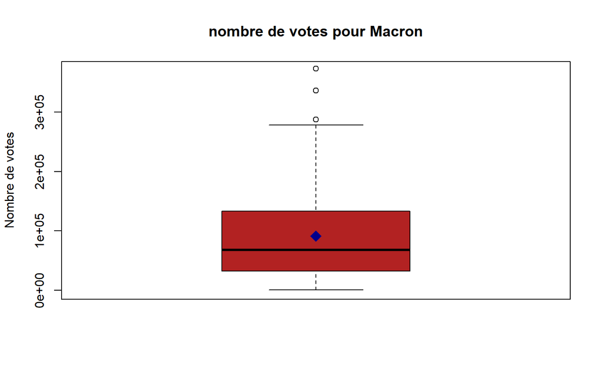

```r
boxplot(Votes$VoteMA, main = "nombre de votes pour Macron",
        col="firebrick", # couleur boite à moustache
        ylim=c(0,370000),# la valeur de départ et de fin sur l'axe des ordonnées
        ylab="Nombre de votes") #le nombre de votes en ordonnées
moy=mean(Votes$VoteMA, na.rm = TRUE)
points(moy,
       col="darkblue",# couleur du point
       pch=18, # style du point
       cex=2) # taille du point
```

On peut constater que le nombre de votes pour Macron par département lors du premier tour est le plus important notament visible grâce aux quartiles(1er:environ 30000 3ème: environ 130000),à la moyenne égale à environ 100000 et à la médiane de 75000. Cependant des valeurs aberrantes sont notables.

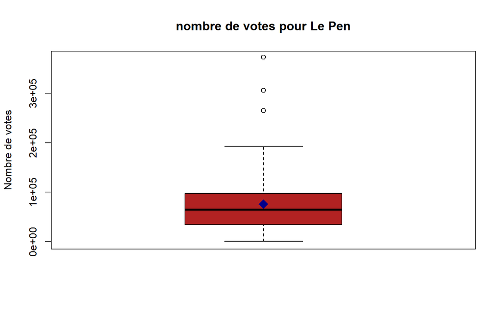

```r
boxplot(Votes$VoteLP, main = "nombre de votes pour Le Pen",
        col="firebrick", # couleur boite à moustache
        ylim=c(0,370000),# la valeur de départ et de fin sur l'axe des ordonnées
        ylab="Nombre de votes") #le nombre de votes en ordonnées
moy=mean(Votes$VoteLP, na.rm = TRUE)
points(moy,
       col="darkblue",# couleur du point
       pch=18, # style du point
       cex=2) # taille du point
```

On peut constater que le nombre de voix pour Marine Le Pen par département lors du premier tour est également significatif on observe une moyenne de 75000 et une médiane de 65000.Bien que certaines valeurs aberrantes soient à noter.

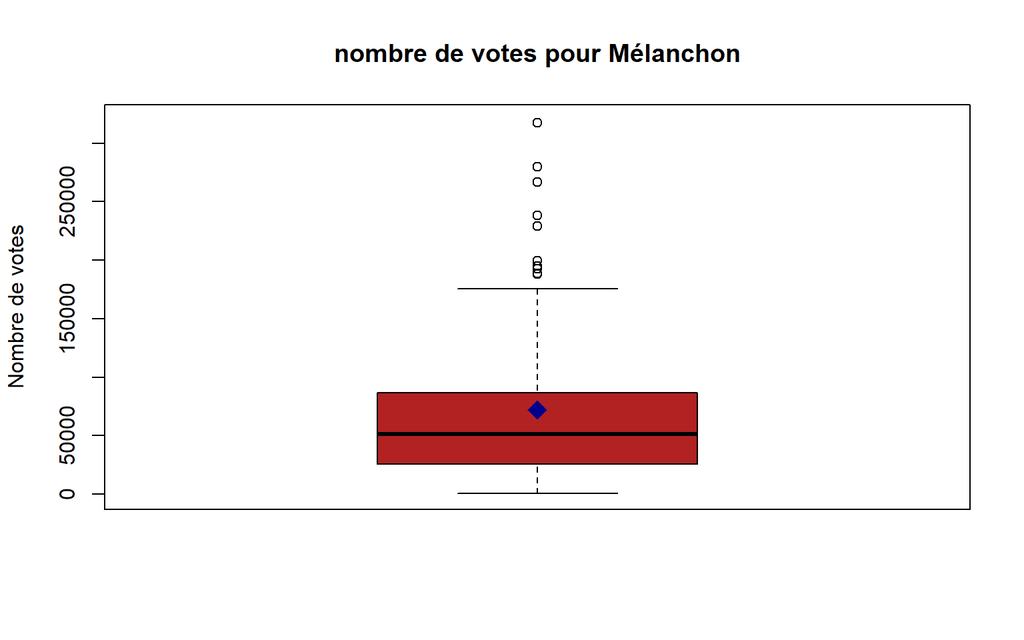

```r
boxplot(Votes$VoteME, main = "nombre de votes pour Mélanchon",
        col="firebrick", # couleur boite à moustache
        ylim=c(0,320000),# la valeur de départ et de fin sur l'axe des ordonnées
        ylab="Nombre de votes") #le nombre de votes en ordonnées
moy=mean(Votes$VoteME, na.rm = TRUE)
points(moy,
       col="darkblue",# couleur du point
       pch=18, # style du point
       cex=2) # taille du point
```

On peut constater que le nombre de voix pour Mélanchon par département lors du premier tour n’est pas très loin derrère avec une moyenne d’environ 75000 et une médiane de 50000.C’est égalment le candidat avec le plus de valeurs extrêmes.

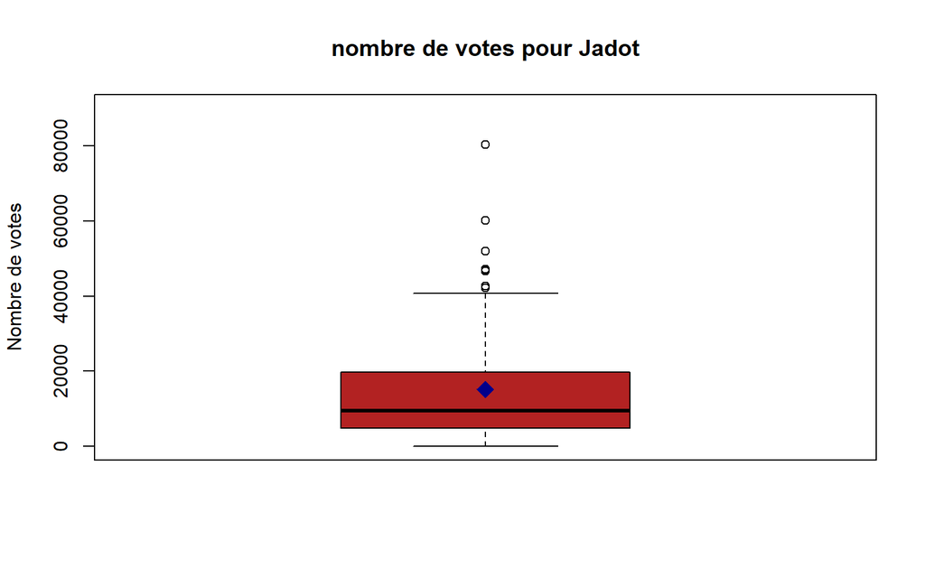

```r
boxplot(Votes$VoteJ, main = "nombre de votes pour Jadot",
        col="firebrick", # couleur boite à moustache
        ylim=c(0,90000),# la valeur de départ et de fin sur l'axe des ordonnées
        ylab="Nombre de votes") #le nombre de votes en ordonnées
moy=mean(Votes$VoteJ, na.rm = TRUE)
points(moy,
       col="darkblue",# couleur du point
       pch=18, # style du point
       cex=2) # taille du point
```

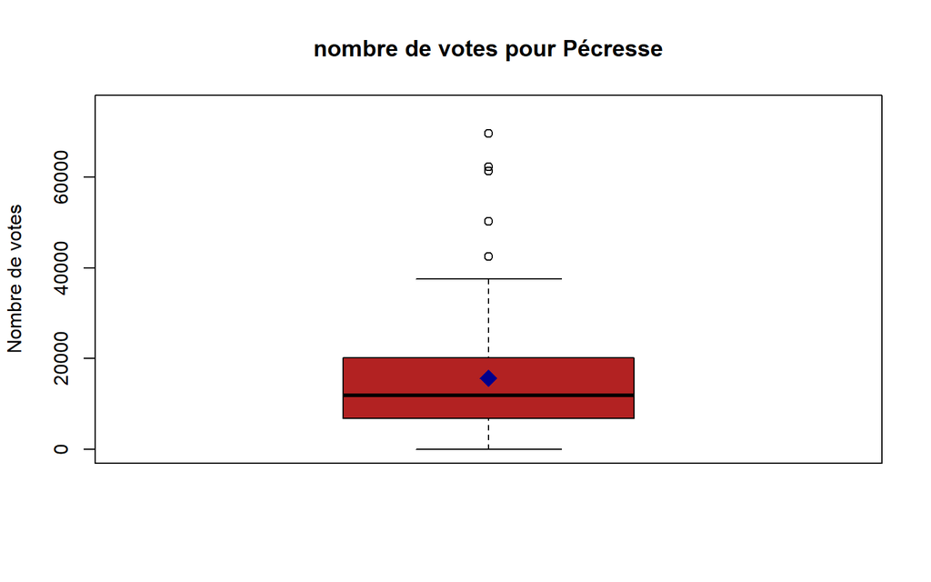

```r
boxplot(Votes$VoteP, main = "nombre de votes pour Pécresse",
        col="firebrick", # couleur boite à moustache
        ylim=c(0,75000),# la valeur de départ et de fin sur l'axe des ordonnées
        ylab="Nombre de votes") #le nombre de votes en ordonnées
moy=mean(Votes$VoteP, na.rm = TRUE)
points(moy,
       col="darkblue",# couleur du point
       pch=18, # style du point
       cex=2) # taille du point
```

Comme pour Yannick Jadot, Valérie pécresse a des résultats assez faible lors du premier tour de la présidentielle de 2022 avec une moyenne environ égale à 18000 et une médiane avoisinant les 10000.Au vu du nombre moins élévé de votes, on peut également observer une variablité moins importante que pour les trois premiers candidats.

```r
varvotes<-mean(Votes$VoteMA^2) - mean(Votes$VoteMA)^2# permet de calculer la cariance des votes
print(varvotes)
```

```
## [1] 5908139884
```

Comme on a pu précedement notifier la variance des votes pour le premier tour de la présidentielle de 2022 pour Emmanuel Macron est très importante.

# 3. Analyses bivariées à partir de la variable VotesMA

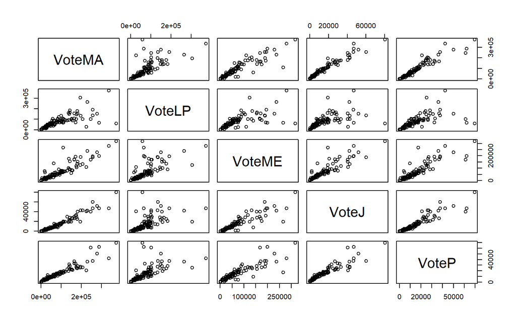

```r
pairs(Votes)# réalise les nuages de points entre les différentes variables
```

## Les corrélations entre tous les couples de variables

```r
round(cor(Votes$VoteMA,Votes$VoteLP),2) #coefficient de rapport de corrélation entre les votes de Macron et ceux de Le Pen
```

```
## [1] 0.72
```

Le rapport de corrélation est le plus faible parmis les 4 autres entre Macron et Le Pen. On peut justifier cela par le bord politique extrême de Le Pen. On peut retrouver ça graphiquement avec un nuage de point étant bien plus dispersé que les autres.

```r
round(cor(Votes$VoteMA,Votes$VoteME),2)#coefficient de rapport de corrélation entre les votes de Macron et ceux de Mélanchon
```

```
## [1] 0.9
```

Le rapport de corrélation est proche de 1 représentant un lien fort entre les votes pour Macron et ceux de Mélanchon mais c’est à relativiser par rapport à celui de Jadot et Pécresse.De plus le nuage de points était bien plus dispersé que ceux avec des bords politiques plus proche de Macron mais plus allongé que celui avec Le Pen.

```r
round(cor(Votes$VoteMA,Votes$VoteJ),2)#coefficient de rapport de corrélation entre les votes de Macron et ceux de Jadot
```

```
## [1] 0.97
```

Le rapport de corrélation est très proche de 1 représentant un lien très fort entre les votes pour Macron et ceux de Jadot. On retrouvait cette corrélation sur le nuage de points allongé e non parallèles à un axe.

```r
round(cor(Votes$VoteMA,Votes$VoteP),2)#coefficient de rapport de corrélation entre les votes de Macron et ceux de Pécresse
```

```
## [1] 0.95
```

Le rapport de corrélation est très proche de 1 représentant un lien très fort entre les votes pour Macron et ceux de Pécresse. On retrouvait cette corrélation sur le nuage de points allongé e non parallèles à un axe.

## Choix de la variable explicative

Étant donné qu’on a le lien de corrélation le plus proche de 1 entre les votes de Macron et ceux de Jadot, notre variable explicative sera les votes de Jadot.

**Séance 2**

# 4. Ajustement linéaire

```r
moyMA<-mean(Votes$VoteMA) #moyenne de votes pour Macron
moyJ<-mean(Votes$VoteJ) #moyenne de votes pour Jadot
produit<-Votes$VoteMA*Votes$VoteJ #calcul pour chaque observation du produit entre les 2 variables



moyproduit<-mean(produit) #moyenne du produit entre les 2 variables
covariance<-moyproduit-(moyMA*moyJ) # covariance entre les 2 variables
varMA<-mean(Votes$VoteMA^2) - mean(Votes$VoteMA)^2 # variance des votes de Macron
varJ<-mean(Votes$VoteJ^2) - mean(Votes$VoteJ)^2 # variance des votes de Jadot
```

```r
var(Votes$VoteMA) # variance pour VoteMA
```

```
## [1] 5963877053
```

```r
var(Votes$VoteJ) # variance pour Votej
```

```
## [1] 219265587
```

```r
cov(Votes$VoteMA,Votes$VoteJ)
```

```
## [1] 1108107272
```

On a calculé les différents indicateurs afin de calculer la covariance entre le nombre de votes pour Macron et le nombre de votes pour Jadot. On trouve ensuite une covariance de **1 108 107 272**, qui va nous permettre par la suite de calculer **a chapeau**, puis de calculer **b chapeau**.

```r
hat_a<-cov(Votes$VoteMA,Votes$VoteJ)/var(Votes$VoteJ) # calcul de "a chapeau" avec la covariance et la variance de VoteJ
hat_b<-moyMA-(hat_a*moyJ) # calcul de "b chapeau" avec moyMA, hat_a et moyJ
print(round(hat_a,2))
```

```
## [1] 5.05
```

```r
print(round(hat_b,2))
```

```
## [1] 14545.25
```

```r
mod1<-lm(formula=VoteMA~VoteJ,data=Votes) # calcul de "a chapeau" et "b chapeau"
summary(mod1)
```

```
##
## Call:
## lm(formula = VoteMA ~ VoteJ, data = Votes)
##
## Residuals:
##    Min     1Q Median     3Q    Max
## -61523  -8035  -1305   5560  84260
##
## Coefficients:
##              Estimate Std. Error t value Pr(>|t|)
## (Intercept) 1.455e+04  2.663e+03   5.463 3.17e-07 ***
## VoteJ       5.054e+00  1.257e-01  40.203  < 2e-16 ***
## ---
## Signif. codes:  0 '***' 0.001 '**' 0.01 '*' 0.05 '.' 0.1 ' ' 1
##
## Residual standard error: 19160 on 105 degrees of freedom
## Multiple R-squared:  0.939,  Adjusted R-squared:  0.9384
## F-statistic:  1616 on 1 and 105 DF,  p-value: < 2.2e-16
```

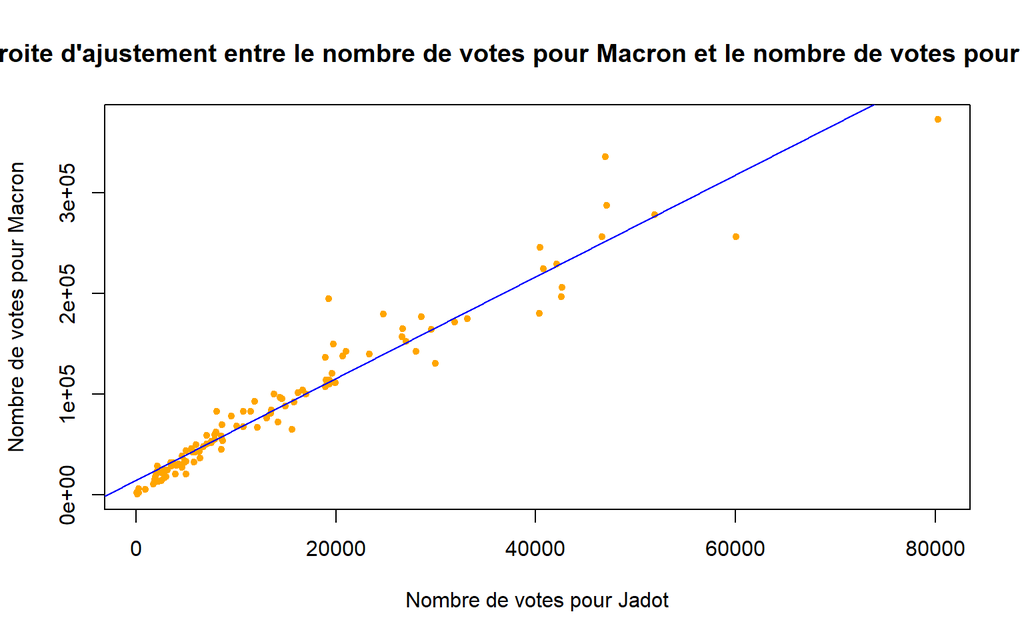

```r
# Nuage de points :
plot(Votes$VoteJ,# VoteJ la variable explicative
Votes$VoteMA, # VoteMA la variable à expliquer
col="orange",pch=20,
xlab="Nombre de votes pour Jadot",
ylab="Nombre de votes pour Macron",
main="Droite d'ajustement entre le nombre de votes pour Macron et le nombre de votes pour Jadot")
# Ajout de la droite d’ajustement :
abline(mod1,col="blue")
```

Nous avons ensuite superposé la droite d’ajustement linéaire au nuage de points représentant la relation entre les votes pour Yannick Jadot et ceux pour Emmanuel Macron. Le nuage de point est étiré vers le haut, cela revient à dire plus le nombre de votes pour Jadot prend de l’ampleur , plus le nombre de votes pour Macron va croitre.A noter, le nuage de point semble étiré selon une droite linéaire proportionnel, autrement dit les deux variables évoluent à un rythme similaire.

## Quelle est la valeur du coefficient de d´etermination R2 ? du R2 ajusté ?

Ainsi , on trouve une valeur de 0,94 pour R² et une valeur de 0,94 pour le R² ajusté.Cela revient à dire d’après l’ajustement linéaire que 94 % de la variabilité des votes pour Macron peut être expliquée par les votes pour Jadot selon le modèle ajusté.

# 5. Second ajustement entre les votes de Macron et ceux de Jadot

Étant donné que le nuage de points précédent est étiré et allongé, nous avons choisi d’effectuer un second ajustement en utilisant la racine carrée. Après l’ajustement linéaire, cette transformation semble être la plus appropriée.

```r
mod_sqrt <- lm(sqrt(VoteMA) ~ sqrt(VoteJ), data = Votes)# calcul de "a chapeau" et "b chapeau"
summary(mod_sqrt)
```

```
##
## Call:
## lm(formula = sqrt(VoteMA) ~ sqrt(VoteJ), data = Votes)
##
## Residuals:
##     Min      1Q  Median      3Q     Max
## -62.738  -9.829  -0.076  14.150 102.473
##
## Coefficients:
##             Estimate Std. Error t value Pr(>|t|)
## (Intercept) 36.98481    5.37198   6.885 4.38e-10 ***
## sqrt(VoteJ)  2.17188    0.04355  49.868  < 2e-16 ***
## ---
## Signif. codes:  0 '***' 0.001 '**' 0.01 '*' 0.05 '.' 0.1 ' ' 1
##
## Residual standard error: 25.09 on 105 degrees of freedom
## Multiple R-squared:  0.9595, Adjusted R-squared:  0.9591
## F-statistic:  2487 on 1 and 105 DF,  p-value: < 2.2e-16
```

Comme précédemment nous avons utilisé la fonction lm de R pour calculer les valeurs de a chapeau et b chapeau ainsi que les valeurs du R² et du R² ajusté pour le modéle ajusté avec une relation à la racine carrée. La valeur du coefficient de détermination R² est de 0,96 et celui du R² ajusté est de 0,96.Cela revient à dire d’après l’ajustement à la racine carrée que 96 % de la variabilité des votes pour Macron peut être expliquée par les votes pour Jadot selon le modèle ajusté.

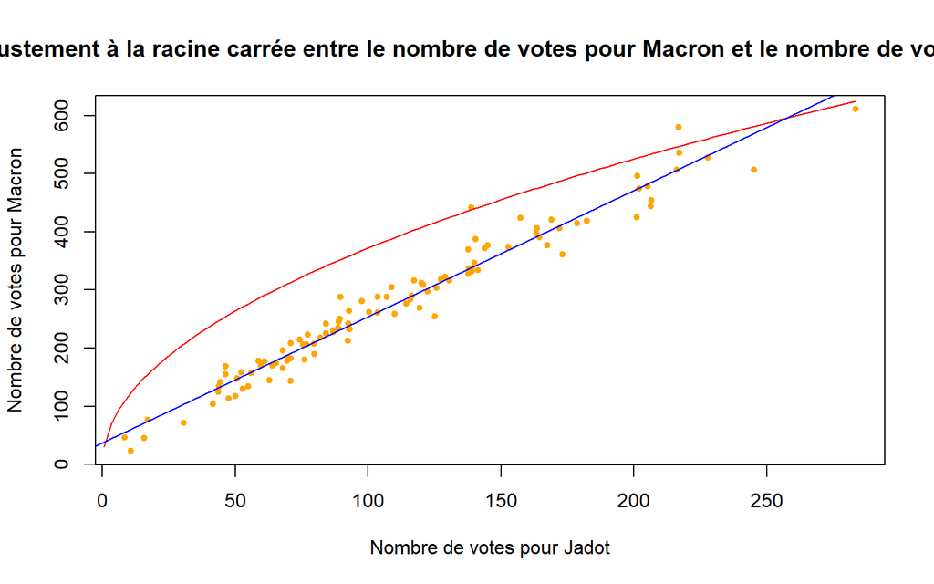

```r
# Nuage de points :
plot(sqrt(Votes$VoteJ),
sqrt(Votes$VoteMA),
col="orange",pch=20,
xlab="Nombre de votes pour Jadot",
ylab="Nombre de votes pour Macron",
main="Droite d'ajustement à la racine carrée entre le nombre de votes pour Macron et le nombre de votes pour Jadot")
# Ajout de la droite d’ajustement :
curve(mod_sqrt$coef[2]+mod_sqrt$coef[1]*sqrt(x),0.60,add=T,col="red")
abline(mod_sqrt,col="blue")
```

**Séance 3**

# 6. Comparaison des deux ajustements

## Quel(s) crit`ere(s) pouvez-vous utiliser pour comparer vos ajustements?

Pour comparer le modèle d’ajustement linéaire et le modèle d’ajustement à la racine carrée ensemble, on peut utiliser le R² ou le R² ajusté car les deux modèles possèdent le même nombre de paramètres (deux).

## Choisissez un critère et comparer vos modèles

Nous allons donc utiliser le R² comme critère pour comparer nos modèles entre eux. Le modèle d’ajustement avec la racine carrée (R² = 0,96) explique légèrement mieux la variation des votes pour Macron que le modèle linéaire (R² = 0,94). Cependant, la différence est minime, donc le choix entre les deux dépendra de la distribution des résidus.

# 7. Valeurs ajustées et qualité d’ajustement du modèle retenu

## Rappelez la définition des résidus

Un résidu est la différence entre la valeur observée yᵢ (VotesMacronᵢ) et la valeur ajustée ŷᵢ(VotesMacronᵢ).Un bon modèle aura des valeurs ajustées ŷᵢ proches des valeurs observées yᵢ.

## Retrouvez la valeur des r´esidus pour chaque ajustement.

```r
residus1<-mod1$residuals;#residus1
```

```r
residus2<-mod_sqrt$residuals;#residus2
```

```r
#* Vérifions que l'on a bien les mêmes valeurs
#cbind(residus1,residus2);
sum(round(residus1,3)!=round(residus2,3)) # renvoie le nombre de départements avec des valeurs différentes pour residus1 et residus2
```

```
## [1] 107
```

On peut en déduire que les résidus des deux modèles sont différents pour chaque observation comme ça correspond à la population.

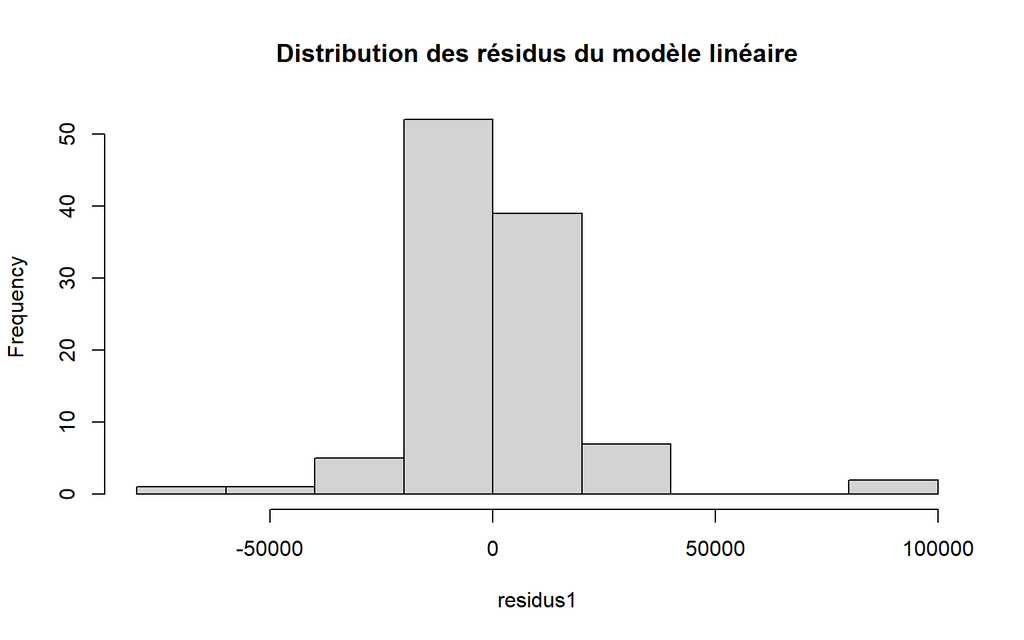

```r
hist(residus1,main="Distribution des résidus du modèle linéaire")
```

On observe une distribution plutôt centrée autour de 0. Les valeurs des résidus sont majoritairement réparties entre -50000 et 50000. On observe une asymétrie à gauche.

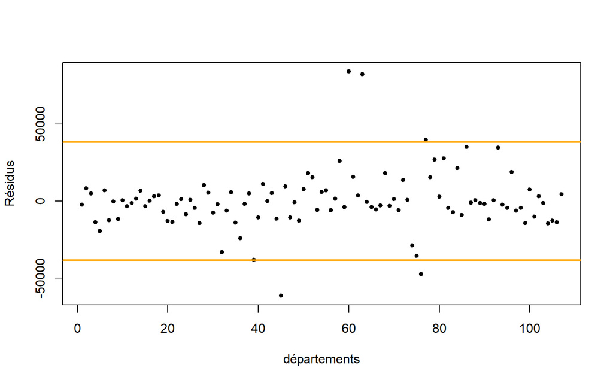

```r
#Récupération la valeur de l'écart-type des résidus
sigma_res<-summary(mod1)$sigma

# Construction du graphique
plot(1:nrow(Votes),residus1,pch=20,xlab="départements",
             ylab="Résidus")

# Ajout des deux droites
abline(h=2*sigma_res,col="orange",lwd=2)
abline(h=-2*sigma_res,col="orange",lwd=2)
```

```r
nrow(Votes[which(abs(residus1)>2*sigma_res),]);# nombre de départements mal expliqués
```

```
## [1] 5
```

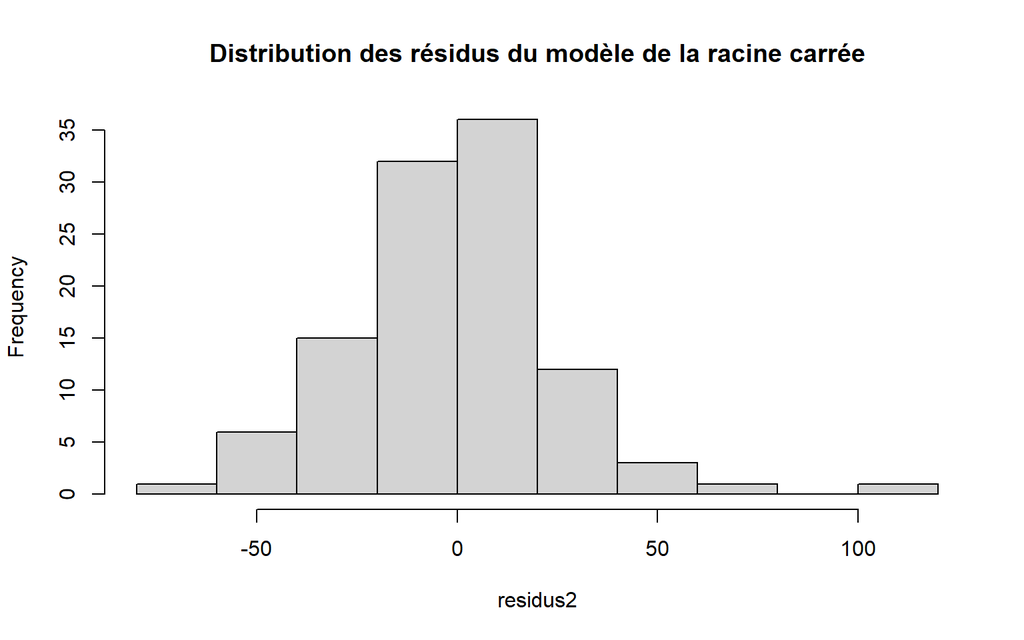

```r
hist(residus2,main="Distribution des résidus du modèle de la racine carrée")
```

On observe une distribution plutôt centrée autour de 0. Les valeurs des résidus sont plutôt réparties entre -50 et 50. On observe une asymétrie à gauche.

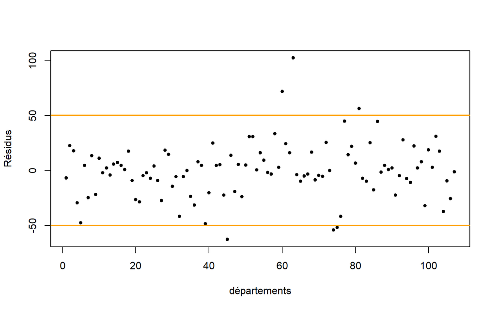

```r
#Récupération la valeur de l'écart-type des résidus
sigma_res<-summary(mod_sqrt)$sigma

# Construction du graphique
plot(1:nrow(Votes),residus2,pch=20,xlab="départements",
             ylab="Résidus")

# Ajout des deux droites
abline(h=2*sigma_res,col="orange",lwd=2)
abline(h=-2*sigma_res,col="orange",lwd=2)
```

Ce graphique permet de mettre en évidence les observatiosn (ici les départemetns) qui sont mal expliqués par le modèle. Ces observations ont un résidus considéré comme trop élevé en valeur absolue. Sur le graphique on peut voir qu’il y a 6 observations atypiques.

```r
nrow(Votes[which(abs(residus2)>2*sigma_res),]);# nombre de départements mal expliqués
```

```
## [1] 6
```

Comme on a pu le voir sur le graphique et confirmé par la formule au dessus il y a 6 départements qui sont mal expliqués avec le modèle d’ajustement à la racine carrée.Trois d’entre eux ont été surestimés par le modèles et les troix autres sous estimés.

.

# 8. Conclusion

Auparavant, On avait pu voir que le modèle à la racine carrée avait un R² un peu plus élevé que le modèle linéaire.De plus après analyse des résidus,on a pu constater que le modèle à la racine **mod_sqr** semble être le plus adapté, car il réduit la variabilité des erreurs et les résidus sont concentrés autour de zéro, indiquant un meilleur ajustement. Cependant, quelques observations restent mal expliquées dans le modèle. Donc nous allons retenir le modèle à la racine carrée.